# Variance Homogeneity Test

ChatGPT 4o

2025-01-26

判断两组数据的方差是否相等，通常使用 F检验（F-test）或其他稳健的检验方法（Bartlett’s test、Levene’s test）。此外还可以使用箱线图或残差图、样本方差比值来判断方差是否大致相等。

```r
library(tidyverse) # 加载tidyverse包
library(car) # 加载tidyverse包
library(readr) # 加载readr包
library(readxl) # 加载readxl包

# datafile <- read_excel(file.choose()) # 读取Excel文件
datafile <- read_excel("BMI.xlsx") # 读取Excel文件
# datafile <- read_csv("test.csv") # 读取Excel文件
datafile <- datafile %>%
  rename(height = "身高",
         weight = "体重",
         gender = "性别",
         attitude = "态度"
         ) # 对变量进行重命名

# F test
var.test(height ~ gender, data = datafile)
```

```
##
##  F test to compare two variances
##
## data:  height by gender
## F = 0.41496, num df = 6, denom df = 6, p-value = 0.3086
## alternative hypothesis: true ratio of variances is not equal to 1
## 95 percent confidence interval:
##  0.07130127 2.41494298
## sample estimates:
## ratio of variances
##           0.414956
```

```r
# Levene's test
leveneTest(
  height ~ factor(gender),
  data = datafile
)
```

```
## Levene's Test for Homogeneity of Variance (center = median)
##       Df F value Pr(>F)
## group  1  1.3698 0.2646
##       12
```

```r
# Bartlett's test
bartlett.test(height ~ factor(gender),
              data = datafile)
```

```
##
##  Bartlett test of homogeneity of variances
##
## data:  height by factor(gender)
## Bartlett's K-squared = 1.0384, df = 1, p-value = 0.3082
```

# **1 F-test**

F 检验用于比较两组数据的方差，适用于正态分布数据。

语法：

```r
var.test(x, y, alternative = "two.sided", conf.level = 0.95)
```

其中：

- x, y：要比较的两组数据。
- alternative： “two.sided”：双侧检验（默认），检测方差是否相等。 “less”：检验 x 的方差是否小于 y。 “greater”：检验 x 的方差是否大于 y。
- conf.level：置信水平，默认 95%。

# **2 Bartlett’s Test**

### **Bartlett’s Test 的原理**

Bartlett’s Test 的原假设和备择假设如下：

- **原假设 $H_0$**：所有组的方差相等。
- **备择假设 $H_1$**：至少有一组的方差不同。

#### **公式**

检验统计量 $T$ 的公式为：

$$T = \frac{(N - k) \ln(S^2) - \sum_{i=1}^{k} (n_i - 1) \ln(S_i^2)}{1 +
\frac{1}{3(k-1)} \left(\sum_{i=1}^{k} \frac{1}{n_i - 1} - \frac{1}{N -
k}\right)}$$

其中：

- $N$：总样本数。
- $k$：组数。
- $S^2$：整体样本的加权方差，计算公式为：

$$S^2 = \frac{\sum_{i=1}^{k} (n_i - 1) S_i^2}{N - k}$$

- $n_i$：第 $i$ 组的样本数。
- $S_i^2$：第 $i$ 组的样本方差。

Bartlett’s Test 的检验统计量 $T$ 近似服从 $\chi^2$ 分布，自由度为 $k - 1$。

### **Bartlett’s Test 的适用范围**

- Bartlett’s Test 适用于**正态分布**的数据。
- 对非正态数据，Bartlett’s Test 对偏态较敏感，可能失去检验效能。

如果数据非正态，建议使用更稳健的方法，例如 Levene’s Test。

### **在 R 中使用 Bartlett’s Test**

#### **1. 函数：`bartlett.test()`**

R 提供了内置的 `bartlett.test()` 函数，用于执行 Bartlett’s Test。

#### **2. 示例数据**

```r
# 示例数据
data <- data.frame(
  height = c(160, 165, 170, 155, 150, 145, 175, 180, 165, 160, 150, 155),
  group = c("A", "A", "A", "B", "B", "B", "C", "C", "C", "D", "D", "D")
)
```

#### **3. 运行Bartlett’s Test**

```r
# 检查数据正态性（以每组为单位）
by(data$height, data$group, shapiro.test)
```

```
## data$group: A
##
##  Shapiro-Wilk normality test
##
## data:  dd[x, ]
## W = 1, p-value = 1
##
## ------------------------------------------------------------
## data$group: B
##
##  Shapiro-Wilk normality test
##
## data:  dd[x, ]
## W = 1, p-value = 1
##
## ------------------------------------------------------------
## data$group: C
##
##  Shapiro-Wilk normality test
##
## data:  dd[x, ]
## W = 0.96429, p-value = 0.6369
##
## ------------------------------------------------------------
## data$group: D
##
##  Shapiro-Wilk normality test
##
## data:  dd[x, ]
## W = 1, p-value = 1
```

```r
# 执行 Bartlett's Test
result <- bartlett.test(height ~ group, data = data)

# 查看结果
print(result)
```

```
##
##  Bartlett test of homogeneity of variances
##
## data:  height by group
## Bartlett's K-squared = 0.50223, df = 3, p-value = 0.9184
```

```r
summary(result)
```

```
##           Length Class  Mode
## statistic 1      -none- numeric
## parameter 1      -none- numeric
## p.value   1      -none- numeric
## data.name 1      -none- character
## method    1      -none- character
```

```r
str(result)
```

```
## List of 5
##  $ statistic: Named num 0.502
##   ..- attr(*, "names")= chr "Bartlett's K-squared"
##  $ parameter: Named num 3
##   ..- attr(*, "names")= chr "df"
##  $ p.value  : num 0.918
##  $ data.name: chr "height by group"
##  $ method   : chr "Bartlett test of homogeneity of variances"
##  - attr(*, "class")= chr "htest"
```

#### **4. 输出解释**

运行 `bartlett.test()` 后，输出结果类似如下：

1. 检验统计量 $0.50223$，表明组间方差的差异程度。
2. 自由度 $df = 3$，表示数据中有 4 个组（$4 - 1 = 3$）。
3. p 值为 0.9184，大于 0.05，因此不能拒绝原假设，认为组间方差相等。

这意味着数据满足方差齐性的假设，可以继续执行单因素方差分析（ANOVA）。

### **Bartlett’s Test 的应用场景**

1. **方差齐性检验**： 在执行单因素方差分析（ANOVA）之前，验证分组数据是否满足方差齐性假设。
2. **组间方差比较**： 检查多个实验组的方差是否显著不同。

### **Bartlett’s Test 的优缺点**

#### **优点**

- 非常适合正态分布的数据。
- 是方差齐性检验的一种经典方法。

#### **缺点**

- 对正态性假设敏感。如果数据分布偏离正态，结果可能不准确。
- 对极端值和偏态数据较为敏感。

### **与 Levene’s Test 的对比**

| 特点 | Bartlett’s Test | Levene’s Test |
| --- | --- | --- |
| 正态性假设 | 需要满足正态性 | 不需要严格满足正态性 |
| 稳健性 | 对非正态数据敏感 | 对非正态数据更稳健 |
| 用途 | 用于正态数据的方差齐性检验 | 用于正态和非正态数据的方差齐性检验 |
| 极端值的影响 | 容易受到极端值影响 | 对极端值更稳健 |

### **代码完整示例**

以下是完整的代码示例：

```r
# 示例数据
data <- data.frame(
  height = c(160, 165, 170, 155, 150, 145, 175, 180, 165, 160, 150, 155),
  group = c("A", "A", "A", "B", "B", "B", "C", "C", "C", "D", "D", "D")
)

# 执行 Bartlett's Test
bartlett_result <- bartlett.test(height ~ group, data = data)

# 打印结果
print(bartlett_result)

# 检查数据正态性（以每组为单位）
by(data$height, data$group, shapiro.test)
```

# **3 Levene’s Test**

### **Levene’s Test 的原理**

Levene’s Test 的假设如下：

- **原假设 $H_0$**：所有组的方差相等。
- **备择假设 $H_1$**：至少有一组的方差与其他组不同。

#### **Levene’s Test 的基本过程**：

1. 计算每组数据的偏差 $Z_{ij}$。
2. 计算组内偏差的均值 $Z_{i.}$ 和总体偏差均值 $Z_{..}$。
3. 根据公式计算检验统计量 $W$。
4. 比较 $W$ 与 $F$ 分布的临界值，或通过 p 值判断是否拒绝原假设。

#### **检验统计量公式**

Levene’s Test 的检验统计量 $W$ 定义如下：

$$W = \frac{(N - k)}{(k - 1)} \cdot \frac{\sum_{i=1}^k n_i (Z_{i.} -
Z_{..})^2}{\sum_{i=1}^k \sum_{j=1}^{n_i} (Z_{ij} - Z_{i.})^2}$$

其中：

- $N$：总样本数。
- $k$：组数。
- $n_i$：第 $i$ 组的样本大小。
- $Z_{ij}$：第 $i$ 组中第 $j$ 个样本与其组中心（均值或中位数）的绝对偏差。
  $$Z_{ij} = |Y_{ij} - \text{center}_i|$$
  - 如果 `center` 选用均值：$\text{center}_i = \bar{Y}_i$；
  - 如果 `center` 选用中位数：$\text{center}_i = \text{median}(Y_i)$。
- $Z_{i.}$：第 $i$ 组的 $Z_{ij}$ 的均值。
- $Z_{..}$：所有 $Z_{ij}$ 的总体均值。

#### **公式解释**

- 分子表示组间偏差平方和，衡量组间差异。
- 分母表示组内偏差平方和，衡量组内差异。
- $W$ 服从 $F$ 分布，自由度为 $(k-1, N-k)$。

### **Levene’s Test 的适用范围**

- 数据可以是正态分布或非正态分布。
- 对于存在异常值的数据，Levene’s Test 更稳健。
- 分组变量应为因子型，响应变量应为定量型。

### **在 R 中使用 Levene’s Test**

#### **1. 函数：`leveneTest()`**

`leveneTest()` 是 R 中 **`car`** 包提供的函数，用于执行 Levene’s Test。

#### **2. 示例数据**

```r
# 示例数据
data <- data.frame(
  height = c(160, 165, 170, 155, 150, 145, 175, 180, 165, 160, 150, 155),
  group = c("A", "A", "A", "B", "B", "B", "C", "C", "C", "D", "D", "D")
)
# 如果尚未安装 car 包
# install.packages("car")

# 加载包
# library(car)
```

```r
# 执行 Levene’s Test，默认以中位数为中心，即center = "median"
result <- leveneTest(height ~ as.factor(group), data = data)

# 查看结果
print(result)
```

```
## Levene's Test for Homogeneity of Variance (center = median)
##       Df F value Pr(>F)
## group  3  0.1667 0.9159
##        8
```

```r
summary(result)
```

```
##        Df          F value           Pr(>F)
##  Min.   :3.00   Min.   :0.1667   Min.   :0.9159
##  1st Qu.:4.25   1st Qu.:0.1667   1st Qu.:0.9159
##  Median :5.50   Median :0.1667   Median :0.9159
##  Mean   :5.50   Mean   :0.1667   Mean   :0.9159
##  3rd Qu.:6.75   3rd Qu.:0.1667   3rd Qu.:0.9159
##  Max.   :8.00   Max.   :0.1667   Max.   :0.9159
##                 NA's   :1        NA's   :1
```

```r
str(result)
```

```
## Classes 'anova' and 'data.frame':    2 obs. of  3 variables:
##  $ Df     : int  3 8
##  $ F value: num  0.167 NA
##  $ Pr(>F) : num  0.916 NA
##  - attr(*, "heading")= chr "Levene's Test for Homogeneity of Variance (center = median)"
```

```r
# 上面的结果等价于：先计算每个值与所在组均值的绝对差
data$abs_diff <- abs(data$height - ave(data$height, data$group, FUN = median))

# 再进行单因素方差分析
anova_result <- aov(abs_diff ~ group, data = data)
summary(anova_result)
```

```
##             Df Sum Sq Mean Sq F value Pr(>F)
## group        3   6.25   2.083   0.167  0.916
## Residuals    8 100.00  12.500
```

```r
# 以均值为中心计算
leveneTest(height ~ as.factor(group), data = data, center = "mean")
```

```
## Levene's Test for Homogeneity of Variance (center = "mean")
##       Df F value Pr(>F)
## group  3     0.4 0.7569
##        8
```

```r
# 上面的结果等价于：先计算每个值与所在组均值的绝对差
data$abs_diff <- abs(data$height - ave(data$height, data$group, FUN = mean))

# 再进行单因素方差分析
anova_result <- aov(abs_diff ~ group, data = data)
summary(anova_result)
```

```
##             Df Sum Sq Mean Sq F value Pr(>F)
## group        3  11.11   3.704     0.4  0.757
## Residuals    8  74.07   9.259
```

#### **3. 结果解释**

1. **`F value`**：检验统计量，表示组间偏差的差异程度。
   - 在此结果中，$F = 0.1667$。
2. **`Df`**：自由度，包括组间自由度（$k - 1$）和组内自由度（$N - k$）。
   - 自由度 $Df = 3$ 表示有 4 个组（组间自由度为 $4 - 1 = 3$）。
3. **`Pr(>F)`**：p 值，用于判断是否拒绝原假设。
- 如果 p 值 > 0.05，则不能拒绝原假设，认为组间方差相等。
- 如果 p 值 ≤ 0.05，则拒绝原假设，认为至少有一组的方差与其他组不同。
- 在此结果中，$p = 0.9159$，大于 0.05，不能拒绝原假设，说明组间方差没有显著差异。

#### **注意**

- **中心选择的影响**：在默认情况下，Levene’s Test 使用中位数作为中心。如果数据接近正态分布，选择均值可能更合适。
- 结果解读需结合具体数据背景，尤其是在边界 p 值（如接近 0.05）时。

### **Levene’s Test 的中心选择**

`leveneTest()` 默认使用中位数作为中心计算偏差（`center = "median"`），适合非正态分布数据。

如果数据接近正态分布，可以选择均值作为中心：

```r
leveneTest(height ~ group, data = data, center = "mean")
```

### **Levene’s Test 的应用场景**

1. **单因素方差分析（ANOVA）**： 在 ANOVA 中，需要验证数据是否满足方差齐性假设。
2. **处理方差不齐的情况**： 如果方差不齐，可以使用更稳健的方法（如 Welch 方差分析）：

```r
   oneway.test(height ~ group, data = data)
```

### **Levene’s Test 的优缺点**

#### **优点**

- 对非正态分布数据稳健。
- 比 Bartlett’s Test 更适合包含异常值的数据。

#### **缺点**

- 在样本量特别小时，可能检验效能较低。
- 偏态数据仍可能影响结果。

### **代码完整示例**

```r
# 示例数据
data <- data.frame(
  height = c(160, 165, 170, 155, 150, 145, 175, 180, 165, 160, 150, 155),
  group = c("A", "A", "A", "B", "B", "B", "C", "C", "C", "D", "D", "D")
)

# 安装并加载 car 包
install.packages("car")
library(car)

# 执行 Levene’s Test
levene_result <- leveneTest(height ~ group, data = data)

# 打印结果
print(levene_result)

# 以均值为中心计算
leveneTest(height ~ group, data = data, center = "mean")
```

# **4 可视化检查方差差异**

绘制箱线图、标准差条形图等来判断方差是否大致相等.

### **箱线图1**

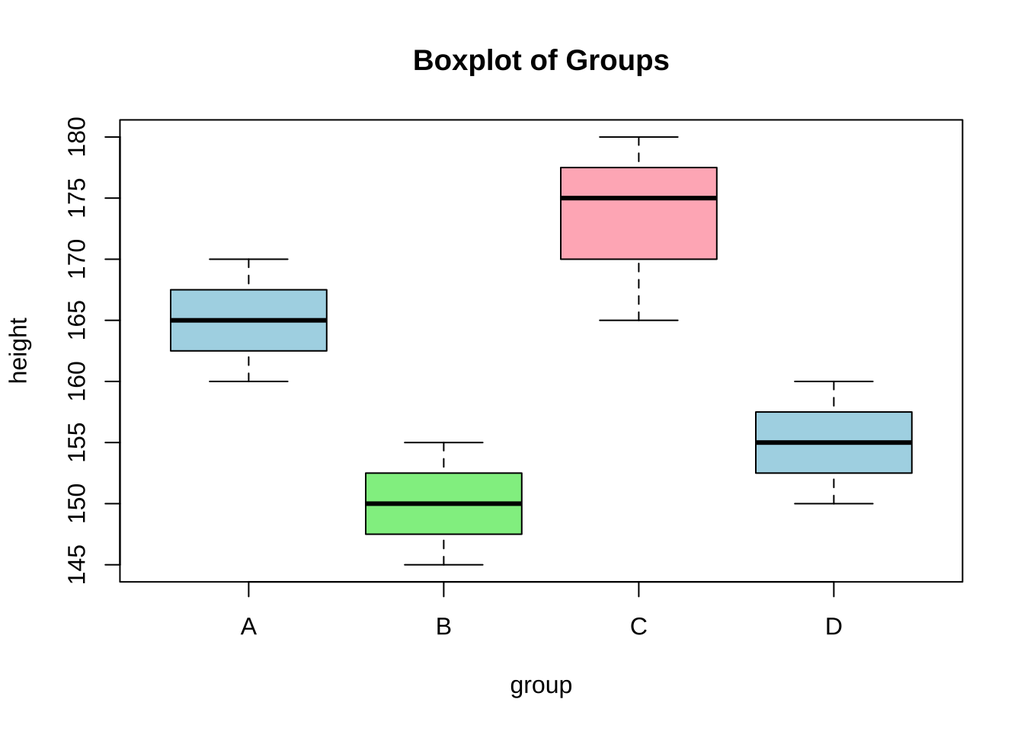

```r
boxplot(height ~ group, data, main = "Boxplot of Groups", col = c("lightblue", "lightgreen","lightpink"))
```

### **箱线图2**

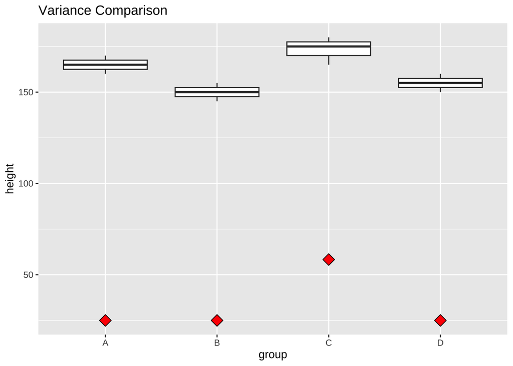

```r
library(ggplot2)
ggplot(data, aes(x = group, y = height)) +
  geom_boxplot() +
  stat_summary(fun = "var", geom = "point", shape = 23, size = 4, fill = "red") +
  labs(title = "Variance Comparison")
```

### **标准差条形图**

```r
# 计算每组均值和标准差
summary_df <- data %>%
  group_by(group) %>%
  summarise(mean_value = mean(height),
            sd_value = sd(height))

print(summary_df)
```

```
## # A tibble: 4 × 3
##   group mean_value sd_value
##   <chr>      <dbl>    <dbl>
## 1 A           165      5
## 2 B           150      5
## 3 C           173.     7.64
## 4 D           155      5
```

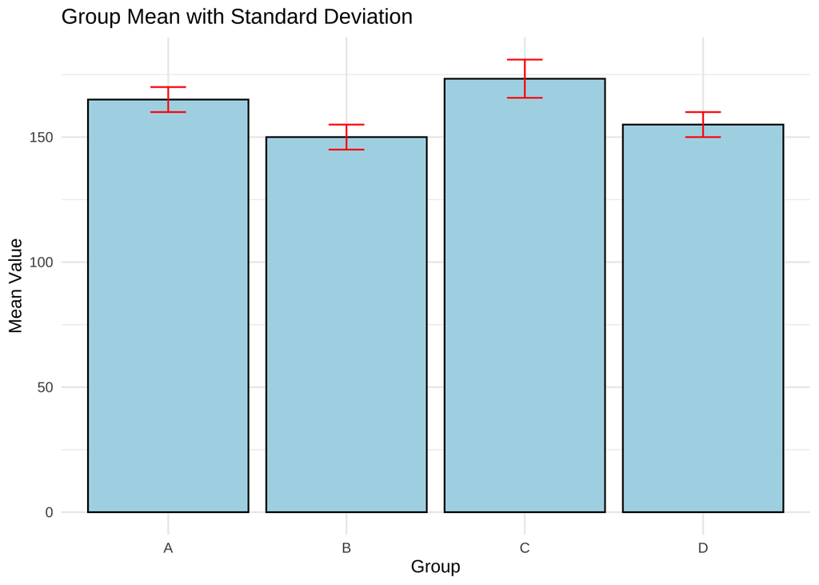

```r
ggplot(summary_df, aes(x = group, y = mean_value)) +
  geom_bar(stat = "identity", fill = "lightblue", color = "black") +  # 条形图
  geom_errorbar(aes(ymin = mean_value - sd_value, ymax = mean_value + sd_value),
                width = 0.2, color = "red") +  # 标准差误差条
  labs(title = "Group Mean with Standard Deviation",
       x = "Group", y = "Mean Value") +
  theme_minimal()
```

# **5 直接比较样本方差**

直接计算样本方差并比较大小，判断方差是否大致相等。